# Importing Dataset and Required Libraries

```python
import numpy as np
import pandas as pd
import seaborn as sns
import matplotlib.pyplot as plt
import researchpy as rp


train = pd.read_csv(r"E:\PROSCHOOL\Term 3\Project\term3.csv")
test = pd.read_csv(r"E:\PROSCHOOL\Term 3\Project\Term end Project.csv")
```

# Safe Copies

```python
df_train = train.copy()
df_test = test.copy()
```

# Dataset View and Information

```python
print("Training Dataset: ")
print(train.head())
print("------"*30)
print("Testing Dataset: ")
print(test.head())
print("------"*30)
print("Training Dataset Info:")
print(train.info())
print("------"*30)
print("Testing Dataset Info:")
print(test.info())
```

```
Training Dataset:
   ID Warehouse_block Mode_of_Shipment  Customer_care_calls  Customer_rating  \
0   1               D           Flight                    4                2
1   2               F           Flight                    4                5
2   3               A           Flight                    2                2
3   4               B           Flight                    3                3
4   5               C           Flight                    2                2

   Cost_of_the_Product  Prior_purchases Product_importance Gender  \
0                  177                3                low      F
1                  216                2                low      M
2                  183                4                low      M
3                  176                4             medium      M
4                  184                3             medium      F

   Discount_offered  Weight_in_gms  Reached.on.Time_Y.N
0                44           1233                    1
1                59           3088                    1
2                48           3374                    1
3                10           1177                    1
4                46           2484                    1
------------------------------------------------------------------------------------------------------------------------------------------------------------------------------------
Testing Dataset:
   ID Warehouse_block Mode_of_Shipment  Customer_care_calls  Customer_rating  \
0   1               A             Road                    3                4
1   2               B             Road                    5                3
2   3               C             Road                    2                2
3   4               F             Road                    4                3
4   5               D             Road                    6                4

   Cost_of_the_Product  Prior_purchases Product_importance Gender  \
0                  168                3                low      M
1                  159                2                low      F
2                  282                3             medium      F
3                  278                4               high      M
4                  256                5                low      F

   Discount_offered  Weight_in_gms  Reached.on.Time_Y.N
0                 5           1841                  NaN
1                58           1990                  NaN
```

[output cut: 28 more lines]

```
ID                     3993 non-null int64
Warehouse_block        3993 non-null object
Mode_of_Shipment       3993 non-null object
Customer_care_calls    3993 non-null int64
Customer_rating        3993 non-null int64
Cost_of_the_Product    3993 non-null int64
Prior_purchases        3993 non-null int64
Product_importance     3993 non-null object
Gender                 3993 non-null object
Discount_offered       3993 non-null int64
Weight_in_gms          3993 non-null int64
Reached.on.Time_Y.N    0 non-null float64
dtypes: float64(1), int64(7), object(4)
memory usage: 374.4+ KB
None
```

1. ID : Id number of customer
2. Warehouse_block : various warehouses own by company
3. Mode_of_shipment : how company transport goods
4. Customer_care_calls : number of calls customer make for enquiry
5. Customer_rating : company has rated every customer
6. Cost_of_product : Price of product in US dollar
7. Prior_purchase : number of purchase made by customer previously
8. Product_importance : product has been categorised on various parameters
9. Gender : Gender of customer
10. Discount_offered : percentage of discount on specific product
11. Weight_in_gms : product weight in grams
12. Reached.on.Time_Y.N : if 1 -> then product not reached on time

    ```
                      if 0 -> then product reached on time
    ```

#### Lets Rename complex target column name to easy one

```python
train.rename(columns ={'Reached.on.Time_Y.N': 'Reached_on_time', 'Discount_offered': 'percent_discount_offered'}, inplace = True)
test.rename(columns ={'Reached.on.Time_Y.N': 'Reached_on_time', 'Discount_offered': 'percent_discount_offered'}, inplace = True)
```

# Check for Null Values

```python
train.isnull().sum()
```

```
ID                          0
Warehouse_block             0
Mode_of_Shipment            0
Customer_care_calls         0
Customer_rating             0
Cost_of_the_Product         0
Prior_purchases             0
Product_importance          0
Gender                      0
percent_discount_offered    0
Weight_in_gms               0
Reached_on_time             0
dtype: int64
```

```python
test.isnull().sum()
```

```
ID                             0
Warehouse_block                0
Mode_of_Shipment               0
Customer_care_calls            0
Customer_rating                0
Cost_of_the_Product            0
Prior_purchases                0
Product_importance             0
Gender                         0
percent_discount_offered       0
Weight_in_gms                  0
Reached_on_time             3993
dtype: int64
```

# Check for Duplicate Rows

```python
print('Duplicate values in trainging set:{}'.format(train.duplicated().sum()))
print('Duplicate values in testing set  :{}'.format(test.duplicated().sum()))
```

```
Duplicate values in trainging set:0
Duplicate values in testing set  :0
```

```python
#Mapping a new labels for "Reached on time" feature in data
train['Reached_on_time'] = train['Reached_on_time'].map({1:'No', 0: 'Yes'})
```

# Describing Numerical Features of data

```python
print(train.describe())
```

```
                ID  Customer_care_calls  Customer_rating  Cost_of_the_Product  \
count  10999.00000         10999.000000     10999.000000         10999.000000
mean    5500.00000             4.054459         2.990545           210.196836
std     3175.28214             1.141490         1.413603            48.063272
min        1.00000             2.000000         1.000000            96.000000
25%     2750.50000             3.000000         2.000000           169.000000
50%     5500.00000             4.000000         3.000000           214.000000
75%     8249.50000             5.000000         4.000000           251.000000
max    10999.00000             7.000000         5.000000           310.000000

       Prior_purchases  percent_discount_offered  Weight_in_gms
count     10999.000000              10999.000000   10999.000000
mean          3.567597                 13.373216    3634.016729
std           1.522860                 16.205527    1635.377251
min           2.000000                  1.000000    1001.000000
25%           3.000000                  4.000000    1839.500000
50%           3.000000                  7.000000    4149.000000
75%           4.000000                 10.000000    5050.000000
max          10.000000                 65.000000    7846.000000
```

```python
train.groupby('Reached_on_time').mean()
```

| Reached_on_time | ID | Customer_care_calls | Customer_rating | Cost_of_the_Product | Prior_purchases | percent_discount_offered | Weight_in_gms |
| --- | --- | --- | --- | --- | --- | --- | --- |
| No | 4424.978364 | 3.991467 | 3.005790 | 207.289197 | 3.498095 | 18.663721 | 3272.640104 |
| Yes | 7090.479486 | 4.147656 | 2.967989 | 214.498647 | 3.670424 | 5.545987 | 4168.668395 |

# Unique values in all features in dataset

#### for training data

```python
variables = ['Warehouse_block', 'Mode_of_Shipment', 'Customer_care_calls','Customer_rating','Prior_purchases','Product_importance', 'Gender','Reached_on_time']
for i in variables:
    print('\n')
    print('Unique values in',i)
    print(train[i].unique())
    print("\n")
    print('***'*10)
```

```
Unique values in Warehouse_block
['D' 'F' 'A' 'B' 'C']




Unique values in Mode_of_Shipment
['Flight' 'Ship' 'Road']




Unique values in Customer_care_calls
[4 2 3 5 6 7]




Unique values in Customer_rating
[2 5 3 1 4]




Unique values in Prior_purchases
[ 3  2  4  6  5  7 10  8]




Unique values in Product_importance
['low' 'medium' 'high']




Unique values in Gender
['F' 'M']




Unique values in Reached_on_time
['No' 'Yes']
```

#### for testing data

```python
variables = ['Warehouse_block', 'Mode_of_Shipment', 'Customer_care_calls','Customer_rating','Prior_purchases','Product_importance', 'Gender']
for i in variables:
    print('\n')
    print('Unique values in',i)
    print(test[i].unique())
    print("\n")
    print('***'*10)
```

```
Unique values in Warehouse_block
['A' 'B' 'C' 'F' 'D']




Unique values in Mode_of_Shipment
['Road' 'Flight' 'Ship']




Unique values in Customer_care_calls
[3 5 2 4 6 7]




Unique values in Customer_rating
[4 3 2 1 5]




Unique values in Prior_purchases
[ 3  2  4  5  6 10  7  8]




Unique values in Product_importance
['low' 'medium' 'high']




Unique values in Gender
['M' 'F']
```

# Describing Categorical and Ordinal Features of data

```python
variables = ['Warehouse_block', 'Mode_of_Shipment', 'Customer_care_calls','Customer_rating','Prior_purchases','Product_importance', 'Gender','Reached_on_time']
rp.summary_cat(train[variables])
```

|  | Variable | Outcome | Count | Percent |
| --- | --- | --- | --- | --- |
| 0 | Warehouse_block | F | 3666 | 33.33 |
| 1 |  | D | 1834 | 16.67 |
| 2 |  | B | 1833 | 16.67 |
| 3 |  | A | 1833 | 16.67 |
| 4 |  | C | 1833 | 16.67 |
| 5 | Mode_of_Shipment | Ship | 7462 | 67.84 |
| 6 |  | Flight | 1777 | 16.16 |
| 7 |  | Road | 1760 | 16.00 |
| 8 | Customer_care_calls | 4 | 3557 | 32.34 |
| 9 |  | 3 | 3217 | 29.25 |
| 10 |  | 5 | 2328 | 21.17 |
| 11 |  | 6 | 1013 | 9.21 |
| 12 |  | 2 | 638 | 5.80 |
| 13 |  | 7 | 246 | 2.24 |
| 14 | Customer_rating | 3 | 2239 | 20.36 |
| 15 |  | 1 | 2235 | 20.32 |
| 16 |  | 4 | 2189 | 19.90 |
| 17 |  | 5 | 2171 | 19.74 |
| 18 |  | 2 | 2165 | 19.68 |
| 19 | Prior_purchases | 3 | 3955 | 35.96 |
| 20 |  | 2 | 2599 | 23.63 |
| 21 |  | 4 | 2155 | 19.59 |
| 22 |  | 5 | 1287 | 11.70 |
| 23 |  | 6 | 561 | 5.10 |
| 24 |  | 10 | 178 | 1.62 |
| 25 |  | 7 | 136 | 1.24 |
| 26 |  | 8 | 128 | 1.16 |
| 27 | Product_importance | low | 5297 | 48.16 |
| 28 |  | medium | 4754 | 43.22 |
| 29 |  | high | 948 | 8.62 |
| 30 | Gender | F | 5545 | 50.41 |
| 31 |  | M | 5454 | 49.59 |
| 32 | Reached_on_time | No | 6563 | 59.67 |
| 33 |  | Yes | 4436 | 40.33 |

1. Most of goods export is from warehouse block F
2. 68% of export done by marine way
3. 48% of product have low importance in data
4. Both male and female have almost equal proportion
5. 60% of product does not reached on time

# Data Visualization

### Univariate Analysis for numerical features

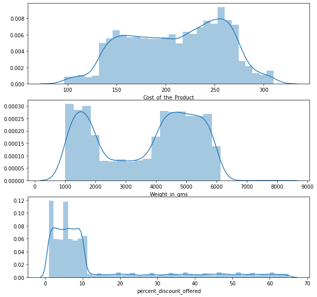

```python
plt.figure(figsize=(10,10))
plt.subplot(311)
sns.distplot(train['Cost_of_the_Product'])
plt.subplot(312)
sns.distplot(train['Weight_in_gms'])
plt.xticks(np.arange(0,10000,1000))
plt.subplot(313)
sns.distplot(train['percent_discount_offered'])
plt.show()
```

1. Most of discount offered in upto 10%
2. Product weight show bimodal distribution i.e, most of product between range of 1kg to 2kg and 4kg and 6kg

### Univariate Analysis for categorical and ordinal features

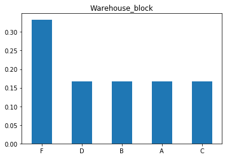

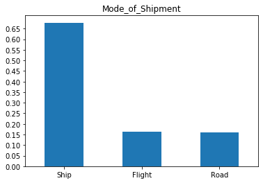

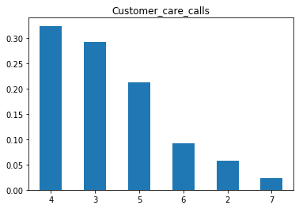

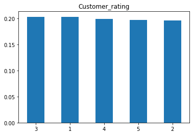

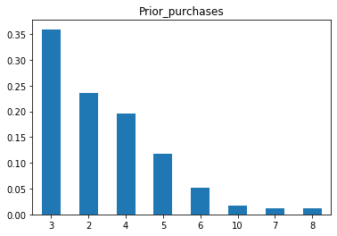

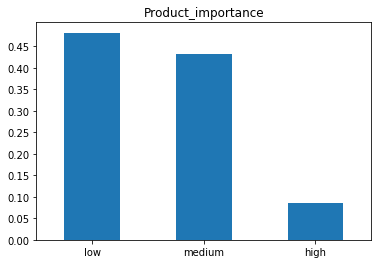

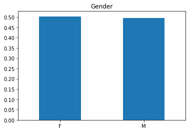

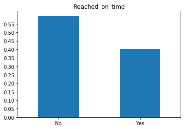

```python
variables = ['Warehouse_block', 'Mode_of_Shipment', 'Customer_care_calls','Customer_rating','Prior_purchases','Product_importance', 'Gender','Reached_on_time']
for i in variables:
    train[i].value_counts(normalize= True).plot.bar()
    plt.xticks(rotation = 0)
    plt.yticks(np.arange(0, train[i].value_counts(normalize= True).max(),0.05))
    plt.title(i)
    plt.show()
```

### Bivariate analysis of Numerical features and target feature

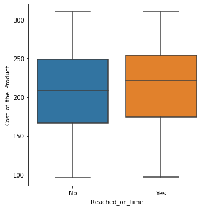

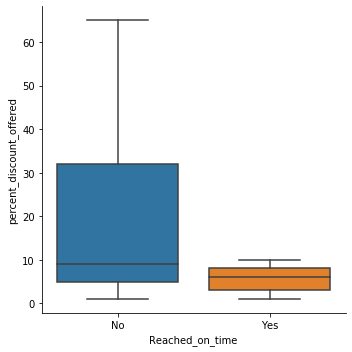

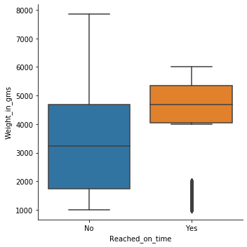

```python
sns.catplot(y='Cost_of_the_Product', x='Reached_on_time',data = train, kind = 'box')
plt.show()

sns.catplot(y='percent_discount_offered', x='Reached_on_time',data = train, kind = 'box')
plt.show()

sns.catplot(y='Weight_in_gms', x='Reached_on_time',data = train, kind = 'box')
plt.show()
```

1. there is no significant insight from cost of product and product reached on time

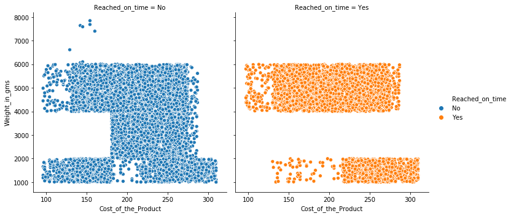

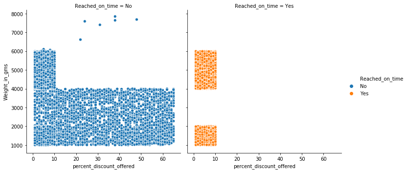

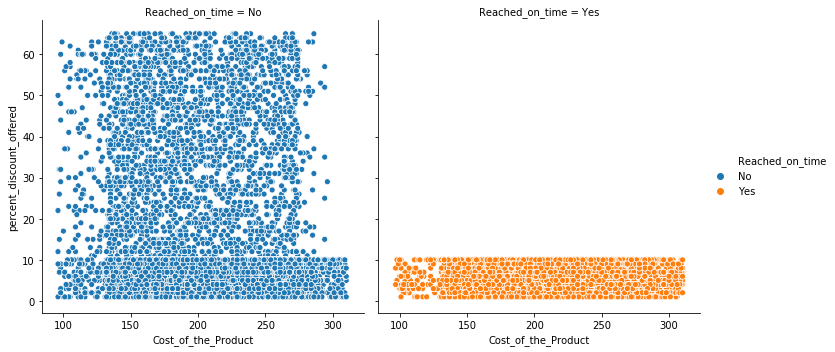

```python
sns.relplot(x = 'Cost_of_the_Product', y = 'Weight_in_gms', data = train, hue = 'Reached_on_time', col = 'Reached_on_time')
plt.show()
sns.relplot(x = 'percent_discount_offered', y = 'Weight_in_gms', data = train, hue = 'Reached_on_time', col = 'Reached_on_time')
plt.show()
sns.relplot(x = 'Cost_of_the_Product', y = 'percent_discount_offered', data = train, hue = 'Reached_on_time', col = 'Reached_on_time')
plt.show()
```

1. Product which reached on time basically sold at low discount
2. And their weight range between 1kg to 2kg and 4kg to 6kg

### Bivariate Analysis of categorical features and target feature

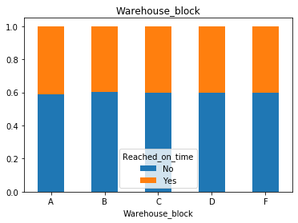

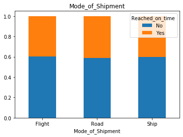

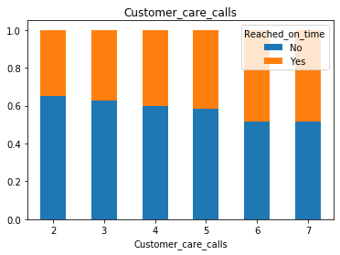

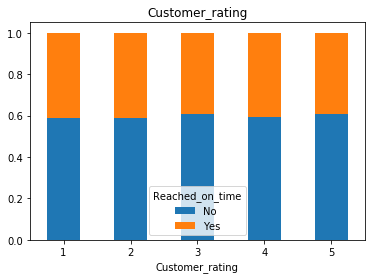

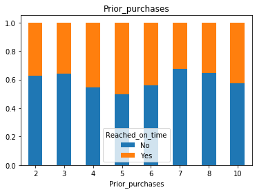

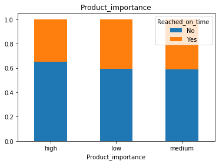

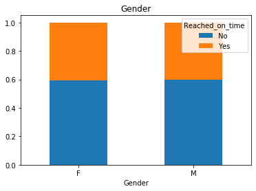

```python
variables = ['Warehouse_block', 'Mode_of_Shipment', 'Customer_care_calls','Customer_rating','Prior_purchases','Product_importance', 'Gender']
for j in variables:
    i = pd.crosstab(train[j], train['Reached_on_time'])
    i.div(i.sum(1),axis = 0).plot.bar(stacked = True)
    plt.title(j)
    plt.xticks(rotation = 0)
    plt.show()
```

1. for warehouse block, Mode of shipment, Customer_rating and Gender, proportion of reached on time or not is same
2. for customer_care_calls,prior_purchases and product_importance shows some variation in proportion

### Understanding relationship between numerical features

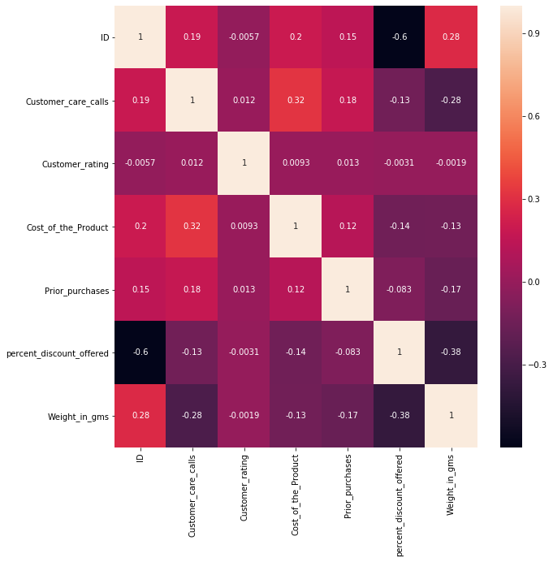

```python
matrix_corr = train.corr()
plt.figure(figsize=(10,10))
sns.heatmap(matrix_corr,annot=True)
plt.show()
```

# Feature Engineering

```python
#Making new categorical column from weight column
def wt_category(num):
    if num <= 2000:
        return('low')
    elif num >4000:
        return('high')
    else:
        return('mid')

train['wt_category']= train['Weight_in_gms'].apply(wt_category)
```

```python
#making new categorical column from discount column
def percent_category(num):
    if num <= 10:
        return('low')
    elif num >10 and num <=30:
        return('mid')
    elif num >30 and num <= 50:
        return('high')
    else:
        return('vhigh')

train['percent_category']=train['percent_discount_offered'].apply(percent_category)
```

```python
#making new column from Prior purchase
def prior_purchase_category(num):
    if num <= 3:
        return('low')
    elif num >= 7:
        return('high')
    else:
        return('mid')

train['Prior_purchase_category']=train.Prior_purchases.apply(prior_purchase_category)
```

```python
#generating column from customers call column
def Customer_call_category(num):
    if num <= 3:
        return('low')
    elif num >=6:
        return('high')
    else:
        return('mid')

train['Customer_call_category']=train.Customer_care_calls.apply(Customer_call_category)
```

Lets check relationship between newly created features and our target variable

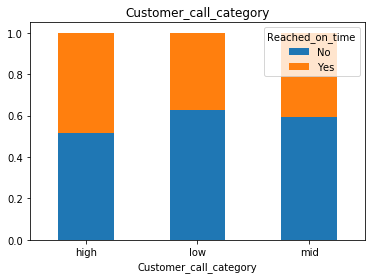

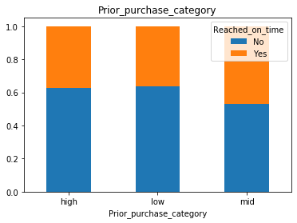

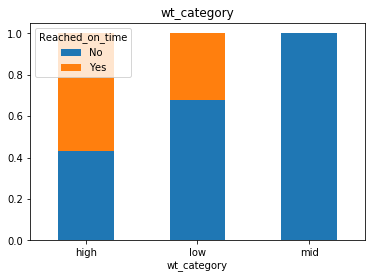

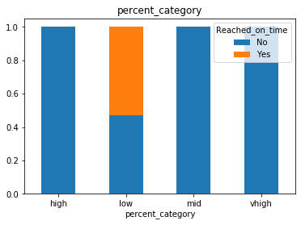

```python
variables=['Customer_call_category', 'Prior_purchase_category',  'wt_category', 'percent_category']

for j in variables:
    i = pd.crosstab(train[j], train['Reached_on_time'])
    i.div(i.sum(1),axis = 0).plot.bar(stacked = True)
    plt.title(j)
    plt.xticks(rotation = 0)
    plt.show()
```

Lets create a new variable "Selling Price" from Cost of product and discount

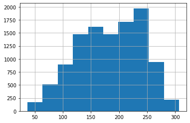

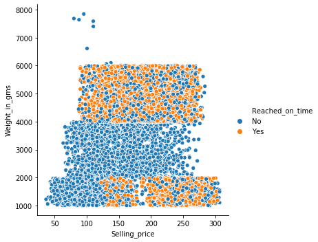

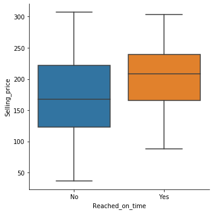

```python
x = train['Cost_of_the_Product']
y = train['percent_discount_offered']
a = np.array(x)
b = np.array(y)
z = a-(a*(b/100))
train['Selling_price']=z

train['Selling_price'].hist()
plt.show()

sns.relplot(x = 'Selling_price', y = 'Weight_in_gms', data = train, hue = 'Reached_on_time')
plt.show()
sns.catplot(x = 'Reached_on_time', y = 'Selling_price', data = train, kind = 'box')
plt.show()
```

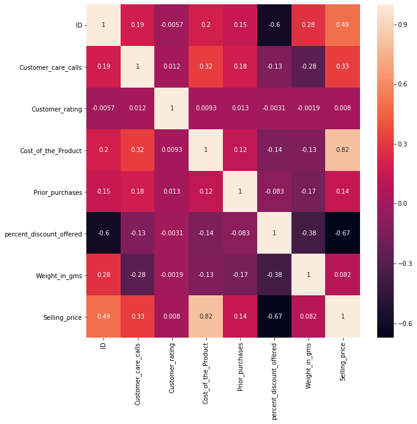

```python
matrix = train.corr()
plt.figure(figsize=(10,10))
sns.heatmap(matrix, annot=True)
plt.show()
```